# South West

For each Provider which appears in the 2017/18 Initial Teacher Training (ITT) Census and which has more than 50 graduates appearing in the School Workforce Census (SWC) a map of Normal Ellipse Curves and a Cumulative Density Curve are included to detail how far the trainees travel to their first job. We only include providers with more than 50 graduates gaining employment over the timeframe as the distribution of distances travelled between graduating and starting first job as NQT will be more reliable for providers with a higher number of entries in the data.

# The Normal Ellipse Maps

A method called Multivariate Normal Confidence Ellipses is used to visualise how far people are travelling from their ITT provider to their first NQT post. This is used to see within what distance trainees are likely to stay after they have finished their ITT.

Normal Ellipses assume the data is distributed according to a bivariate normal distribution[^1]. Each ellipse is a boundary - it is expected that the percentage of trainees associated with that ellipse (e.g. 50% of trainees from that provider) will start their first role as NQT within that confidence ellipse. These ellipses become more accurate with higher volumes of data, which in this case is more trainees.[^2]

The Confidence Ellipses may cover areas where no leaver has ever been (for example over the sea) due to the shape of the bivariate normal distribution being an ellipse.

There is a Normal Confidence Ellipse map for each individual provider with a red point at the location of the provider with size proportional to the number of NQTs who have graduated from the provider between 2010 and 2015 and a map of the 95% confidence intervals for all the providers in the region.

# The Cumulative Density Curve

The cumulative density curve represents the proportion of people from that provider that have travelled that distance or less from leaving the provider to starting their first post as NQT.

# Provider Level Analysis

## University of Gloucestershire

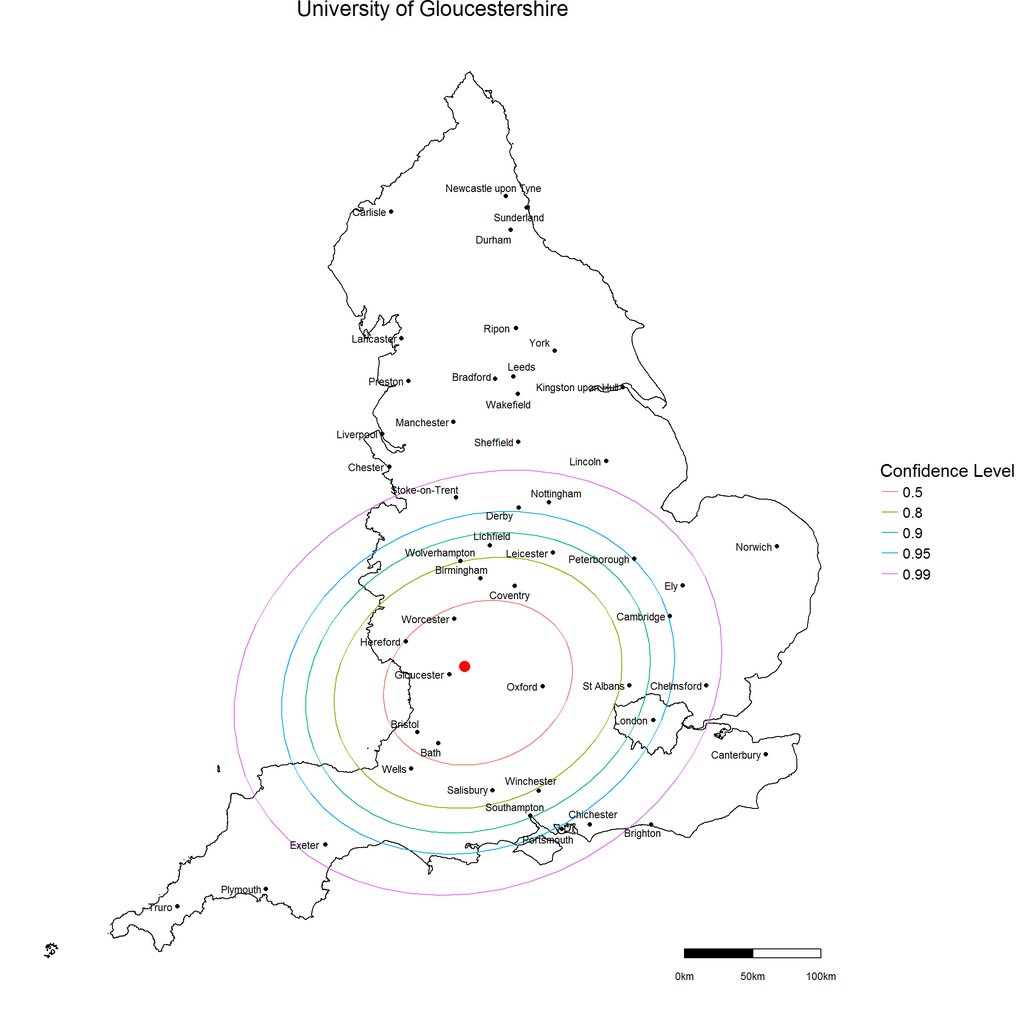

For University of Gloucestershire 34 % of leavers travel 25km or less to their first job as NQT and 20 % travel more than 100km. The percentage of students staying within 25km of University of Gloucestershire is higher than the regional average.

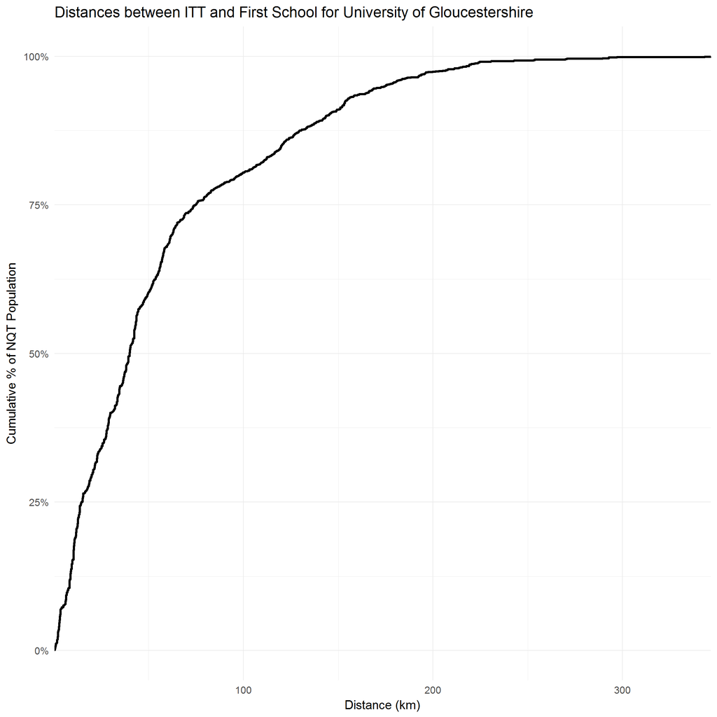

## University of The West of England

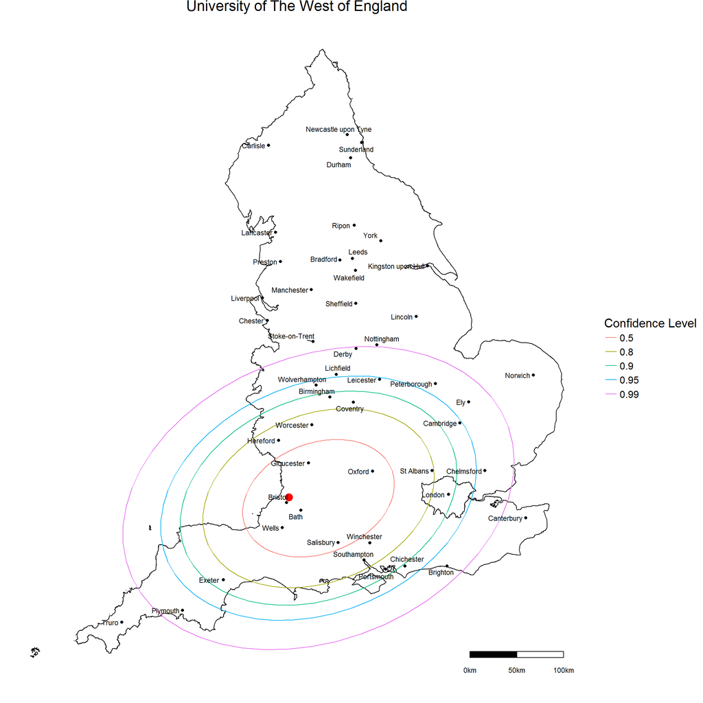

For University of The West of England 46 % of leavers travel 25km or less to their first job as NQT and 28 % travel more than 100km. The percentage of students staying within 25km of University of The West of England is higher than the regional average.

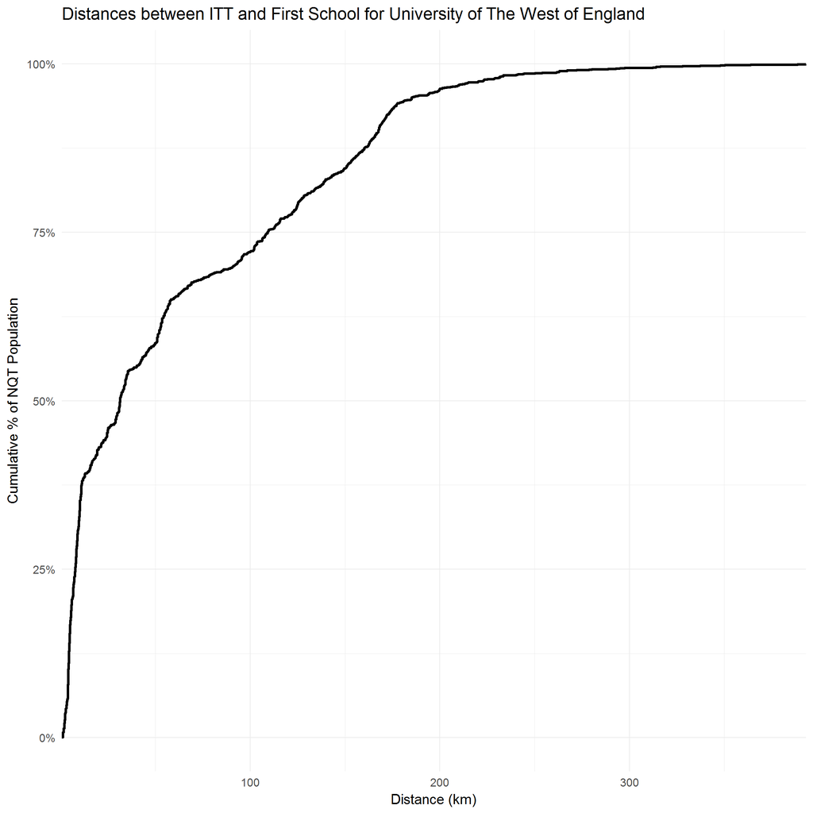

## University of Plymouth

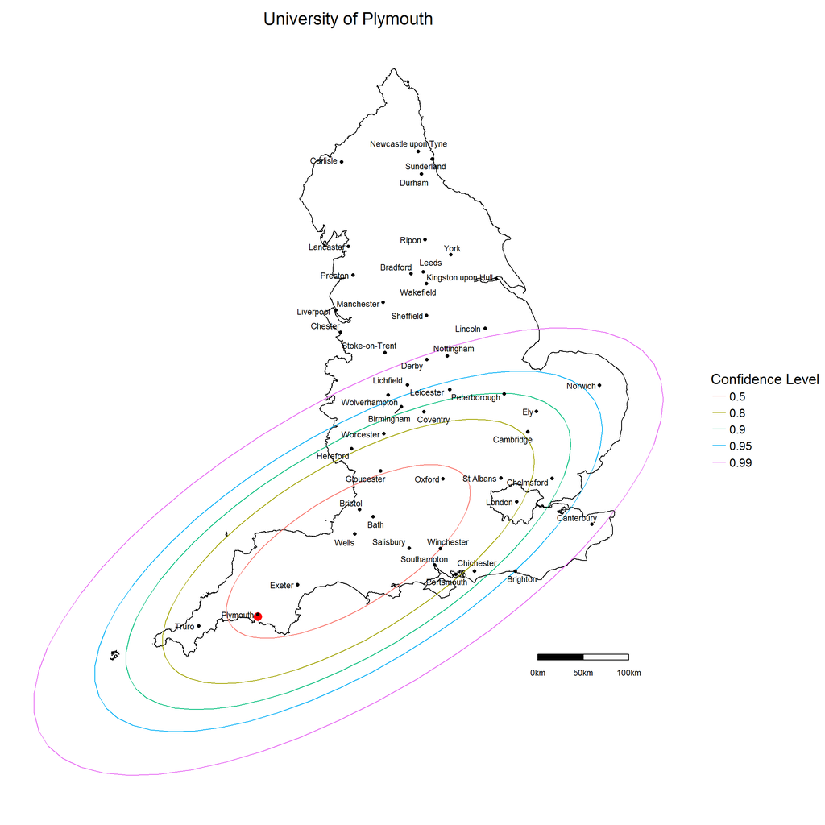

For University of Plymouth 17 % of leavers travel 25km or less to their first job as NQT and 49 % travel more than 100km. The percentage of students staying within 25km of University of Plymouth is lower than the regional average.

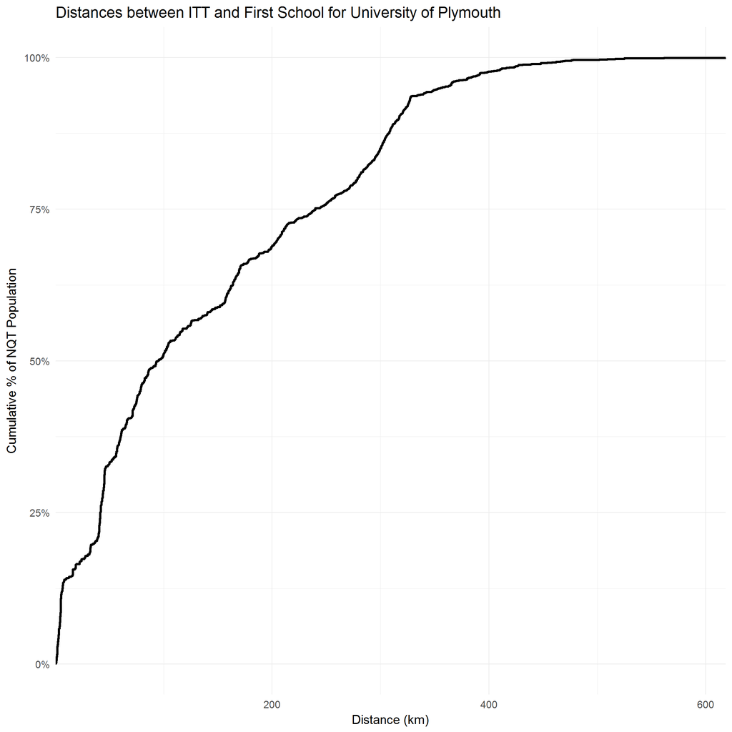

## University of Exeter

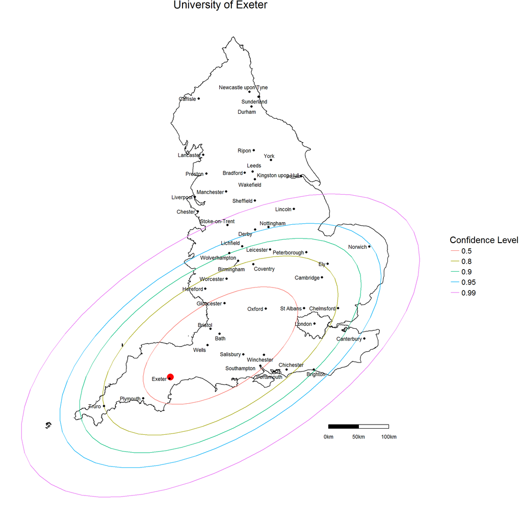

For University of Exeter 14 % of leavers travel 25km or less to their first job as NQT and 51 % travel more than 100km. The percentage of students staying within 25km of University of Exeter is lower than the regional average.

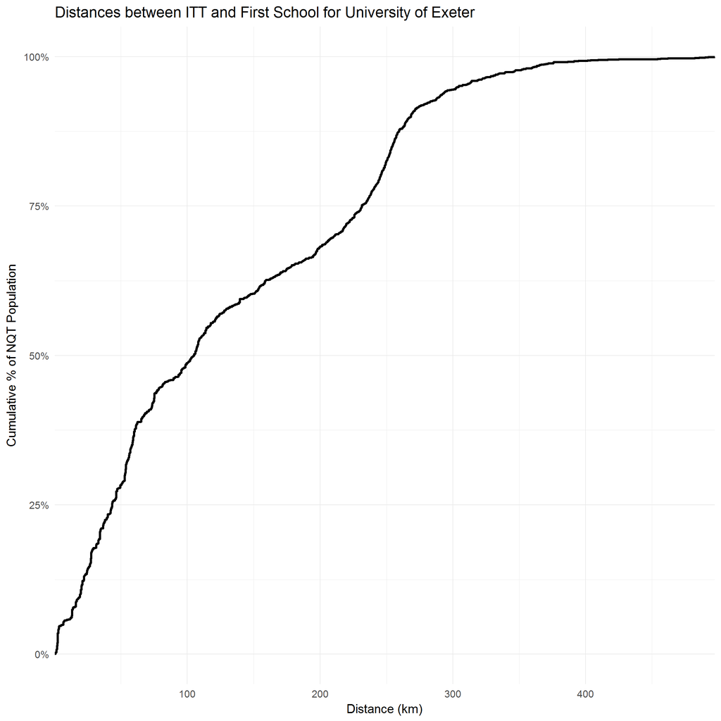

## University of Bristol

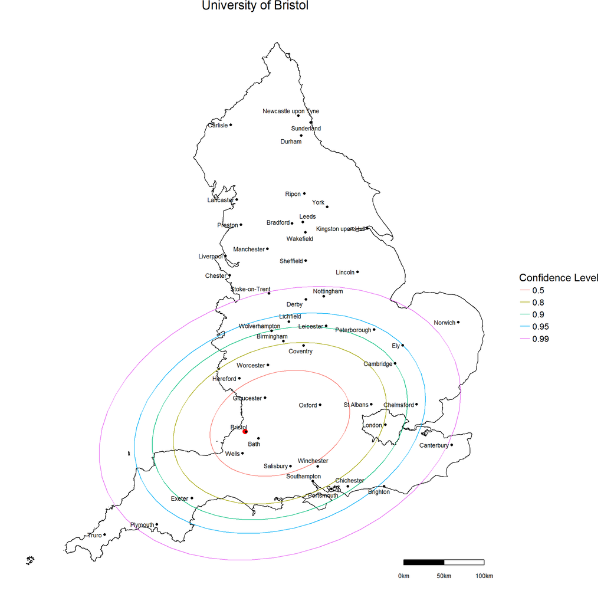

For University of Bristol 43 % of leavers travel 25km or less to their first job as NQT and 30 % travel more than 100km. The percentage of students staying within 25km of University of Bristol is higher than the regional average.

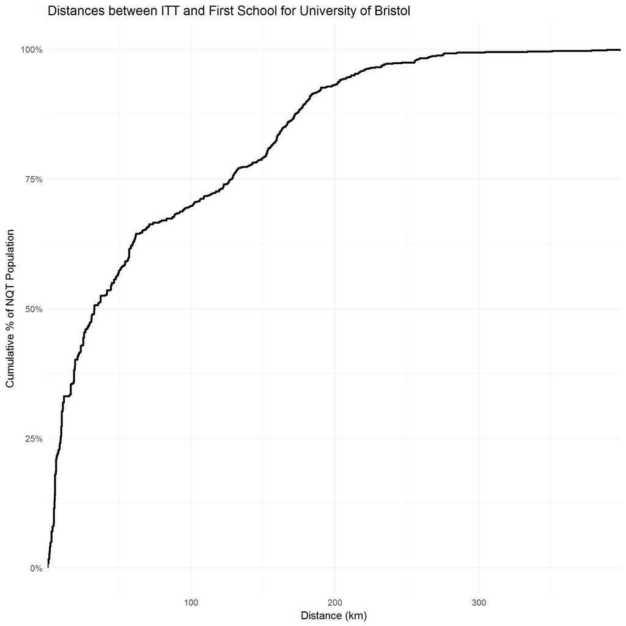

## Bath Spa University

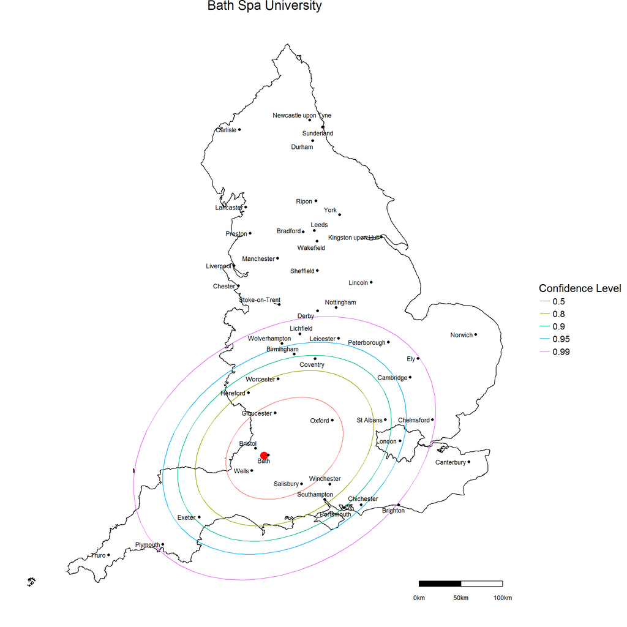

For Bath Spa University 45 % of leavers travel 25km or less to their first job as NQT and 20 % travel more than 100km. The percentage of students staying within 25km of Bath Spa University is higher than the regional average.

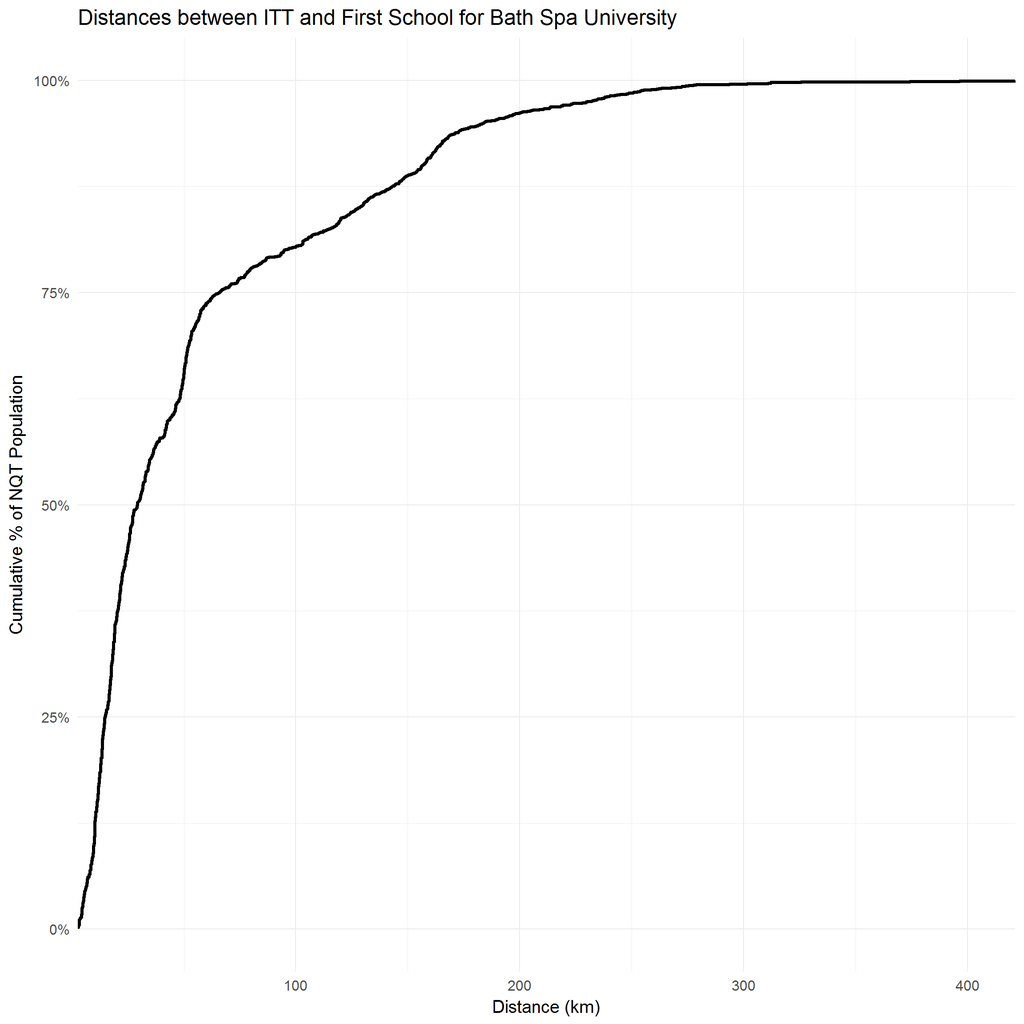

## University of St Mark & St John

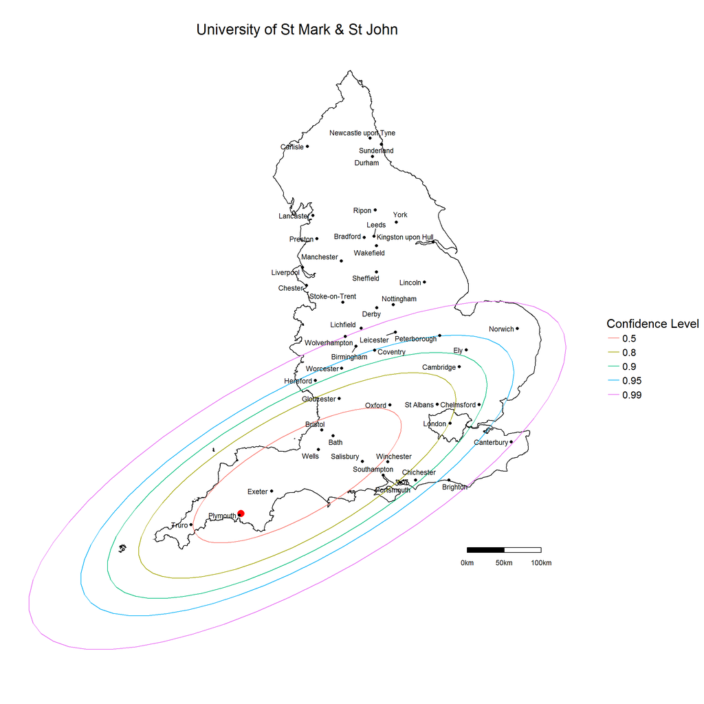

For University of St Mark & St John 28 % of leavers travel 25km or less to their first job as NQT and 38 % travel more than 100km. The percentage of students staying within 25km of University of St Mark & St John is lower than the regional average.

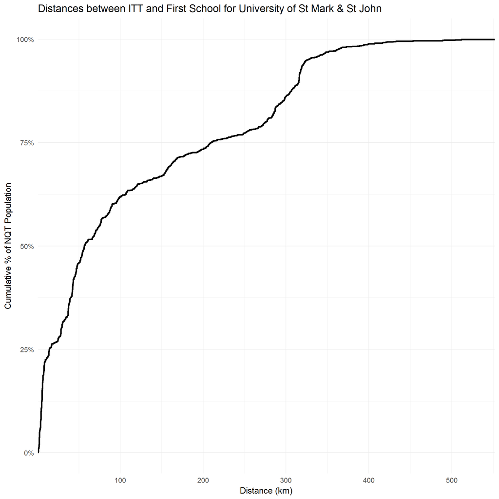

## Devon Primary SCITT

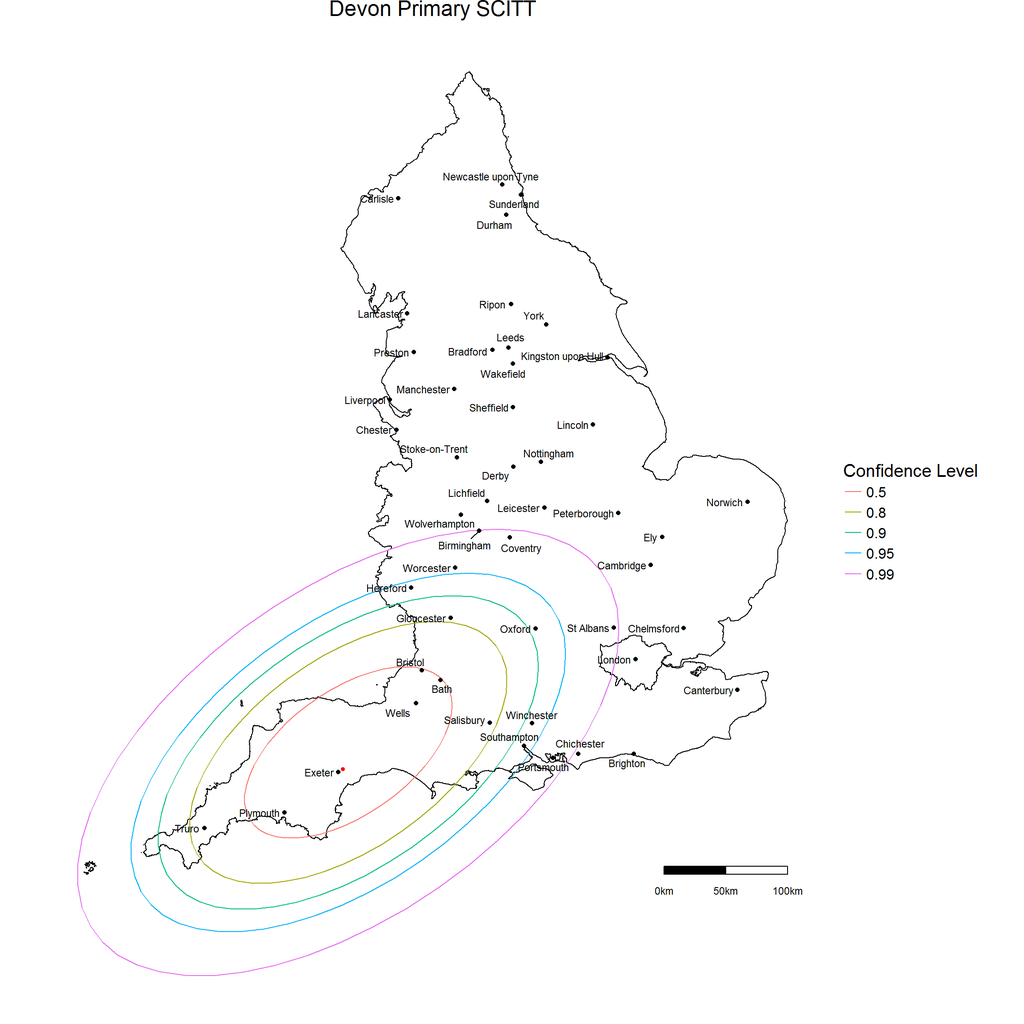

For Devon Primary SCITT 34 % of leavers travel 25km or less to their first job as NQT and 13 % travel more than 100km. The percentage of students staying within 25km of Devon Primary SCITT is higher than the regional average.

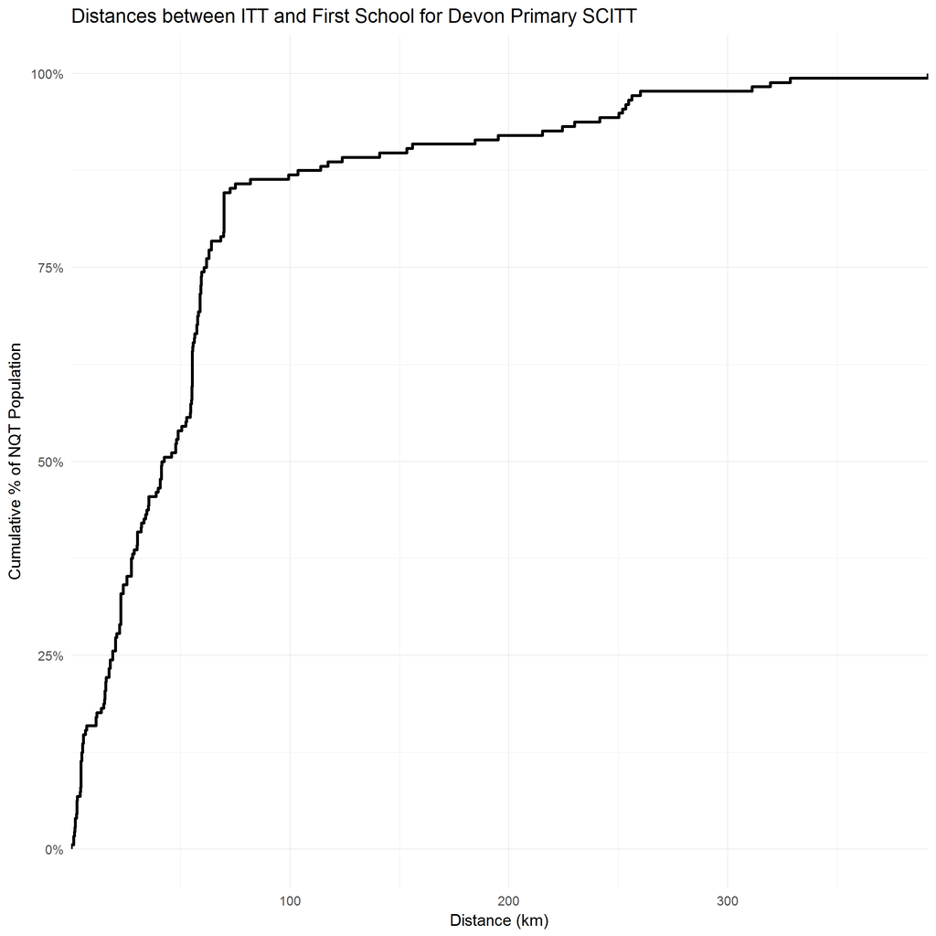

## Swindon Secondary Schools Teaching Alliance Initial Teacher Education (SSSTA ITE)

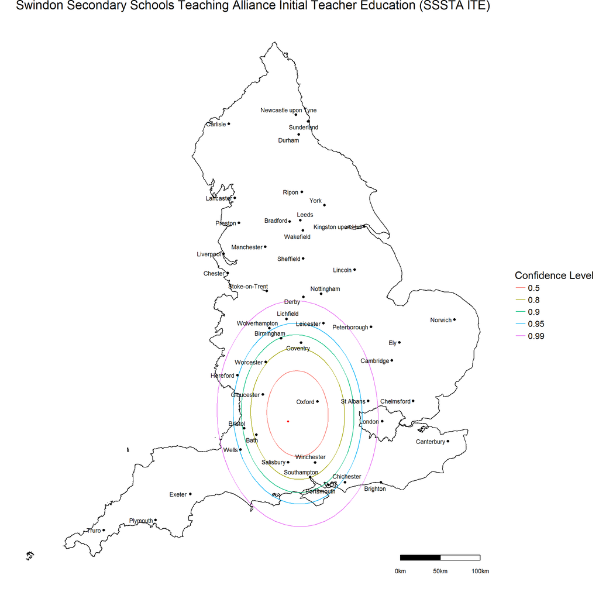

For Swindon Secondary Schools Teaching Alliance Initial Teacher Education (SSSTA ITE) 65 % of leavers travel 25km or less to their first job as NQT and 6 % travel more than 100km. The percentage of students staying within 25km of Swindon Secondary Schools Teaching Alliance Initial Teacher Education (SSSTA ITE) is higher than the regional average.

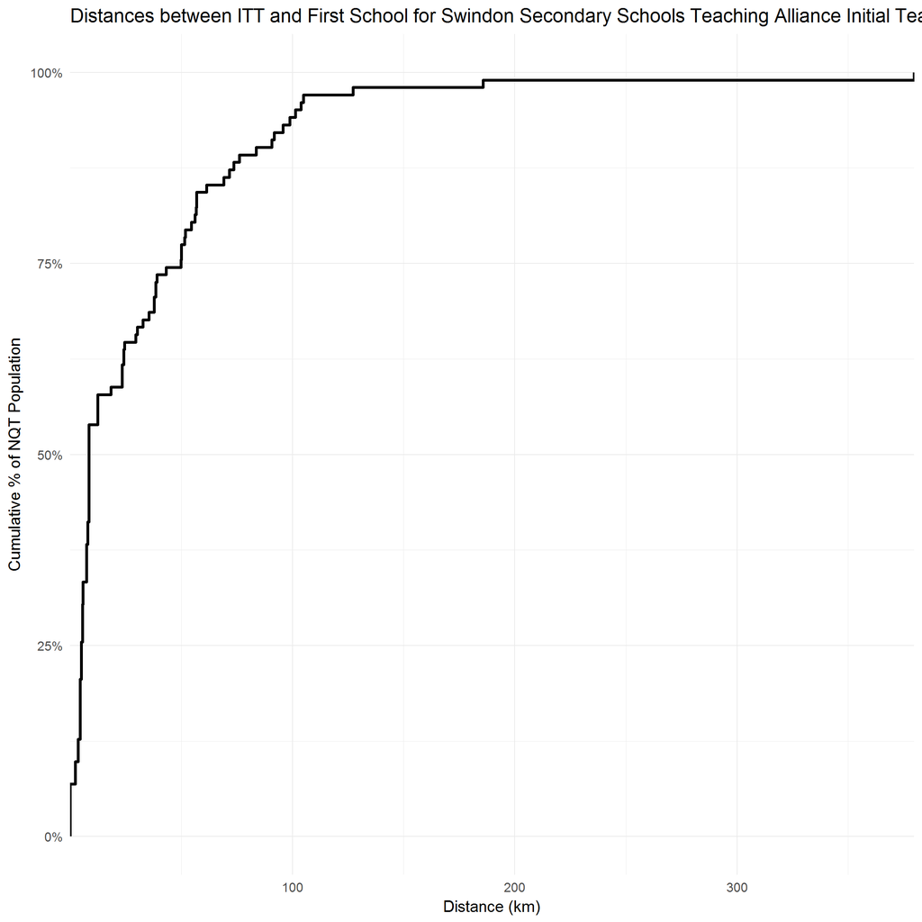

## Bournemouth Poole & Dorset Secondary Training Partnership

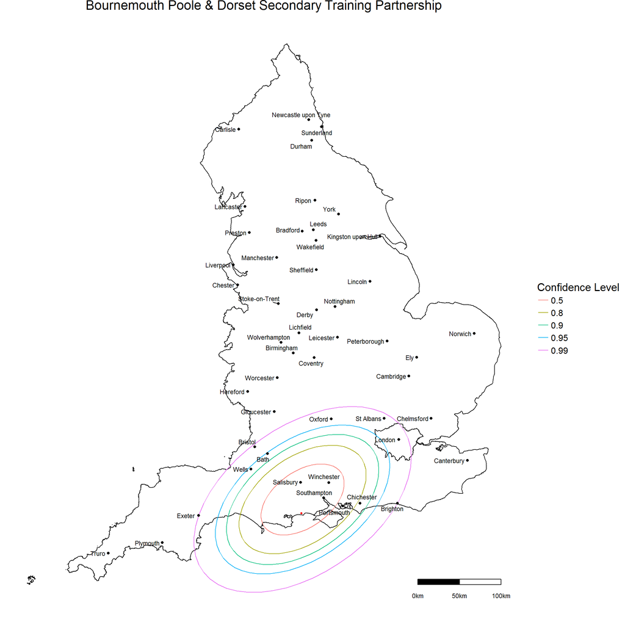

For Bournemouth Poole & Dorset Secondary Training Partnership 61 % of leavers travel 25km or less to their first job as NQT and 9 % travel more than 100km. The percentage of students staying within 25km of Bournemouth Poole & Dorset Secondary Training Partnership is higher than the regional average.

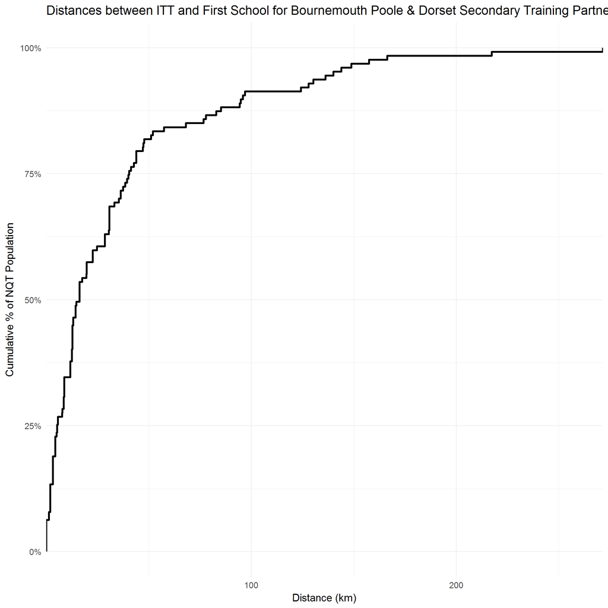

## Somerset SCITT Consortium

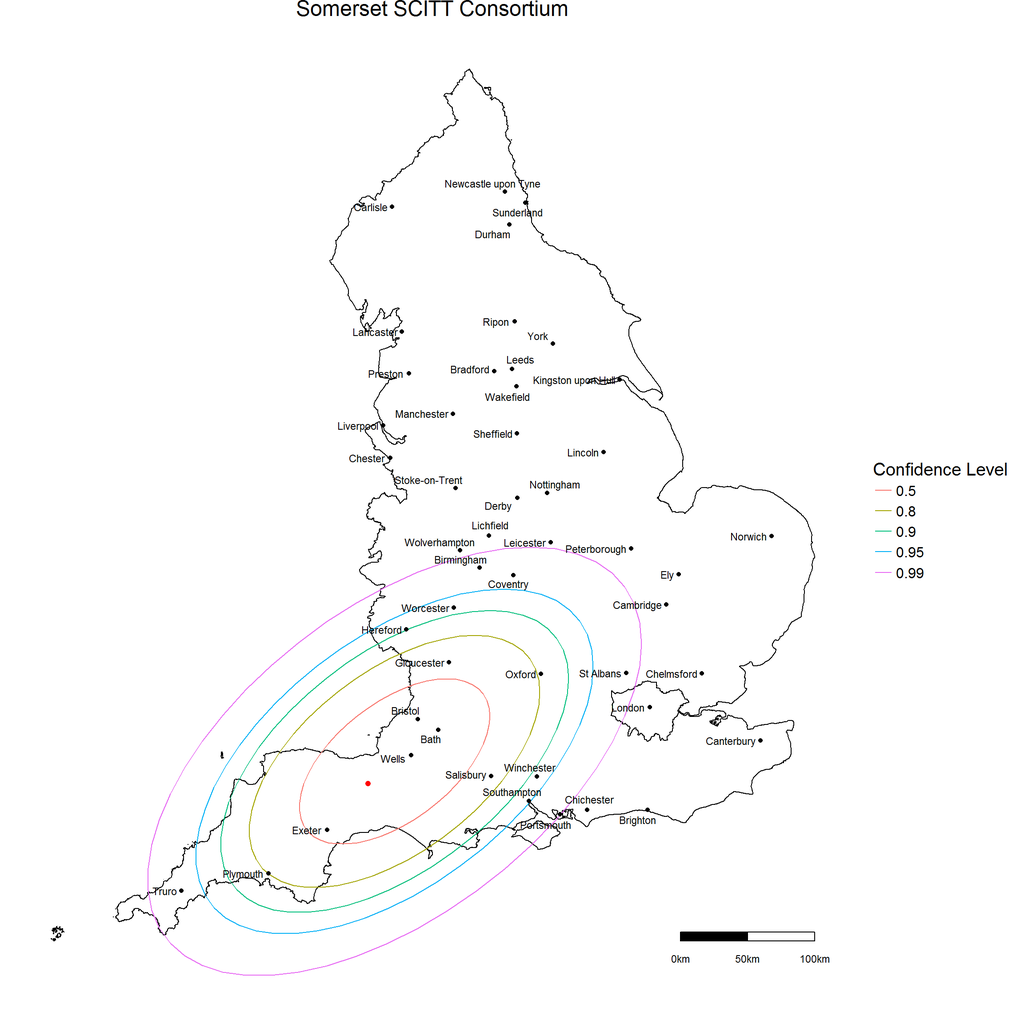

For Somerset SCITT Consortium 38 % of leavers travel 25km or less to their first job as NQT and 14 % travel more than 100km. The percentage of students staying within 25km of Somerset SCITT Consortium is higher than the regional average.

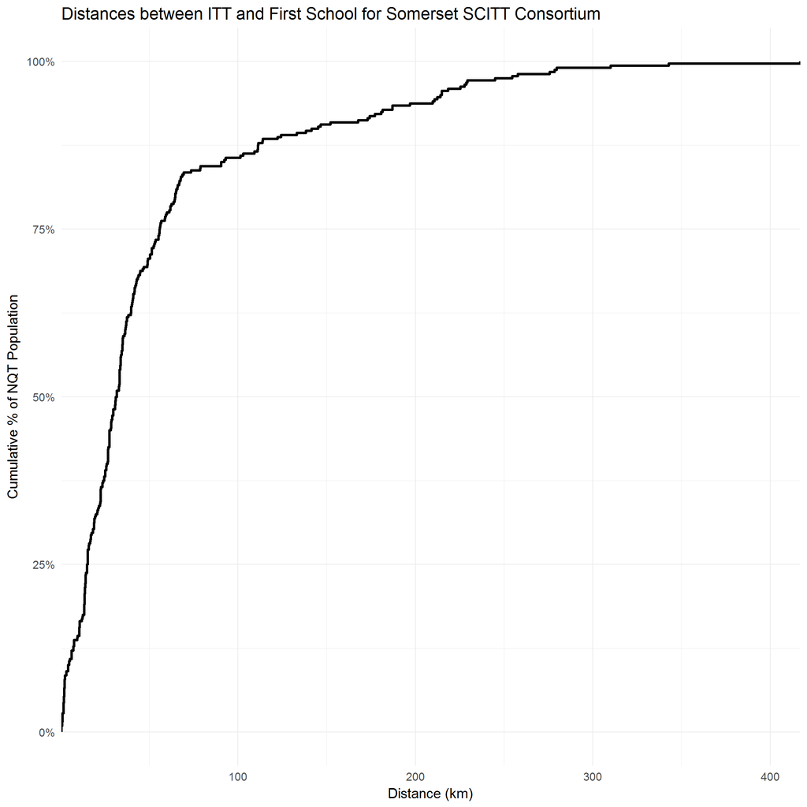

## Gloucestershire Initial Teacher Education Partnership (GITEP)

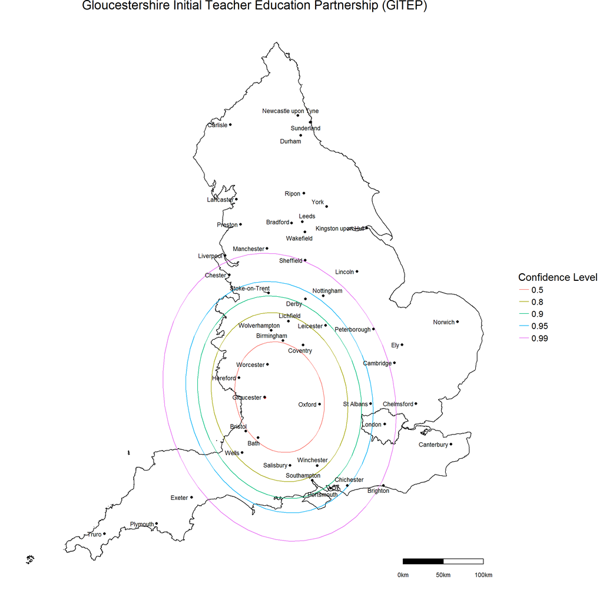

For Gloucestershire Initial Teacher Education Partnership (GITEP) 43 % of leavers travel 25km or less to their first job as NQT and 14 % travel more than 100km. The percentage of students staying within 25km of Gloucestershire Initial Teacher Education Partnership (GITEP) is higher than the regional average.

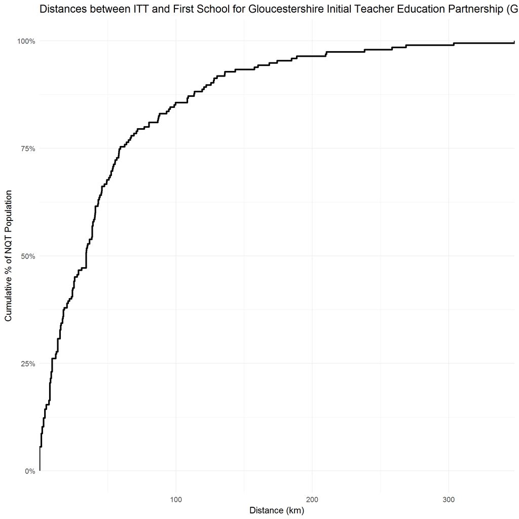

## South West Teacher Training

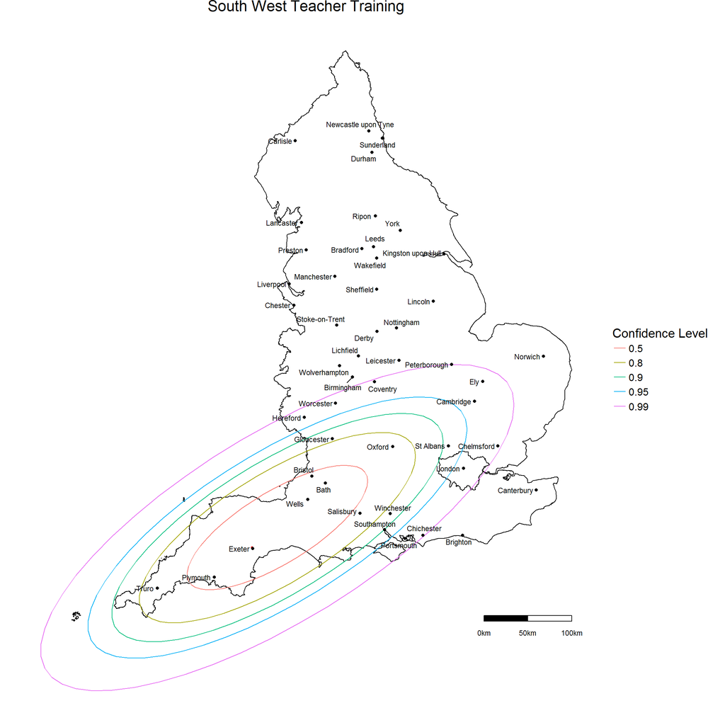

For South West Teacher Training 37 % of leavers travel 25km or less to their first job as NQT and 19 % travel more than 100km. The percentage of students staying within 25km of South West Teacher Training is higher than the regional average.

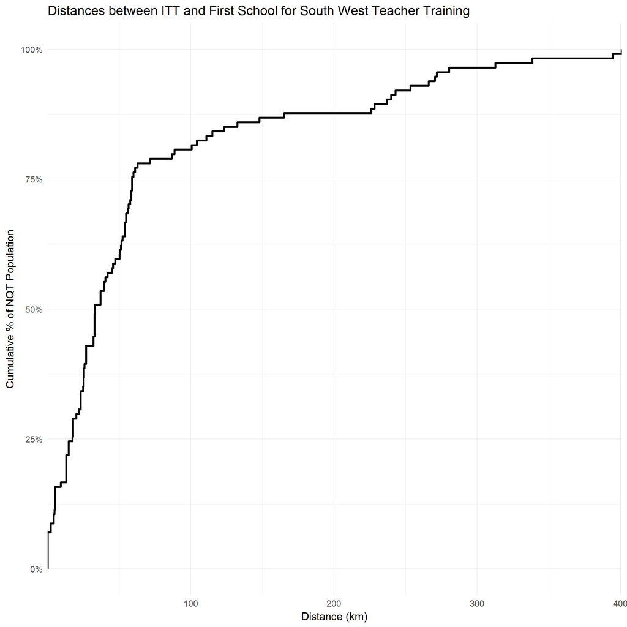

## Cornwall School Centred Initial Teacher Training. (Cornwall SCITT)

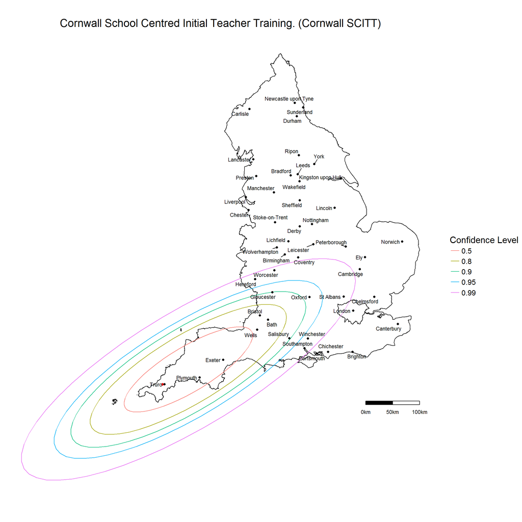

For Cornwall School Centred Initial Teacher Training. (Cornwall SCITT) 54 % of leavers travel 25km or less to their first job as NQT and 19 % travel more than 100km. The percentage of students staying within 25km of Cornwall School Centred Initial Teacher Training. (Cornwall SCITT) is higher than the regional average.

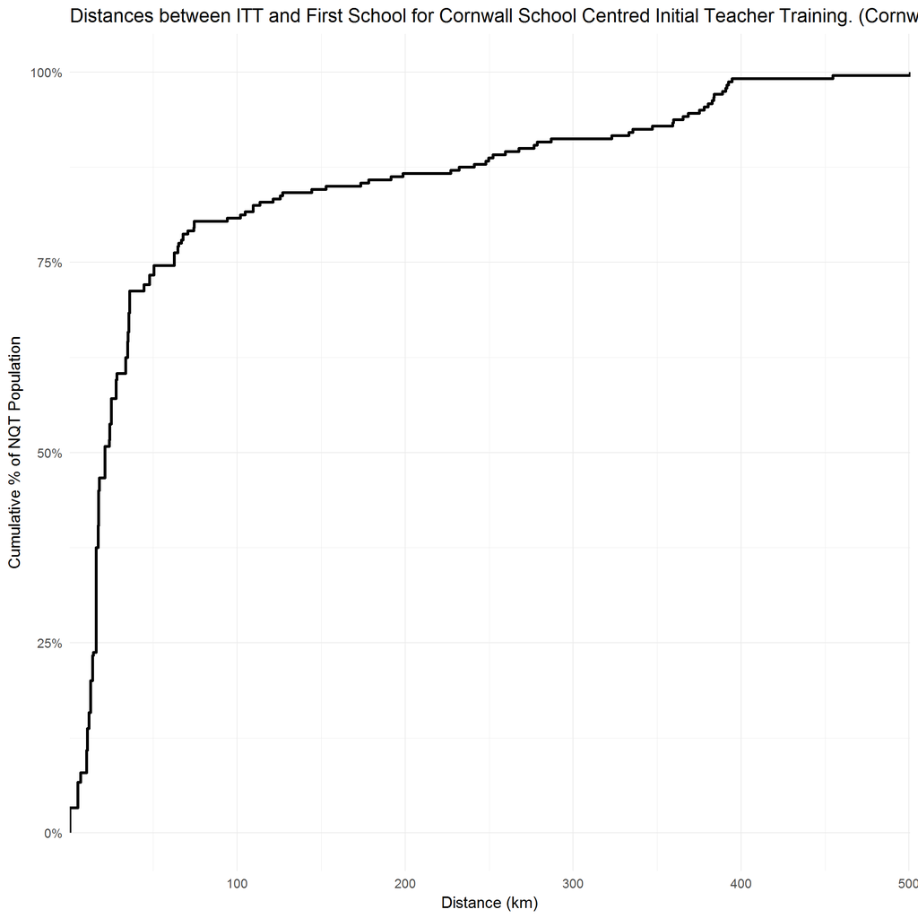

## Poole SCITT

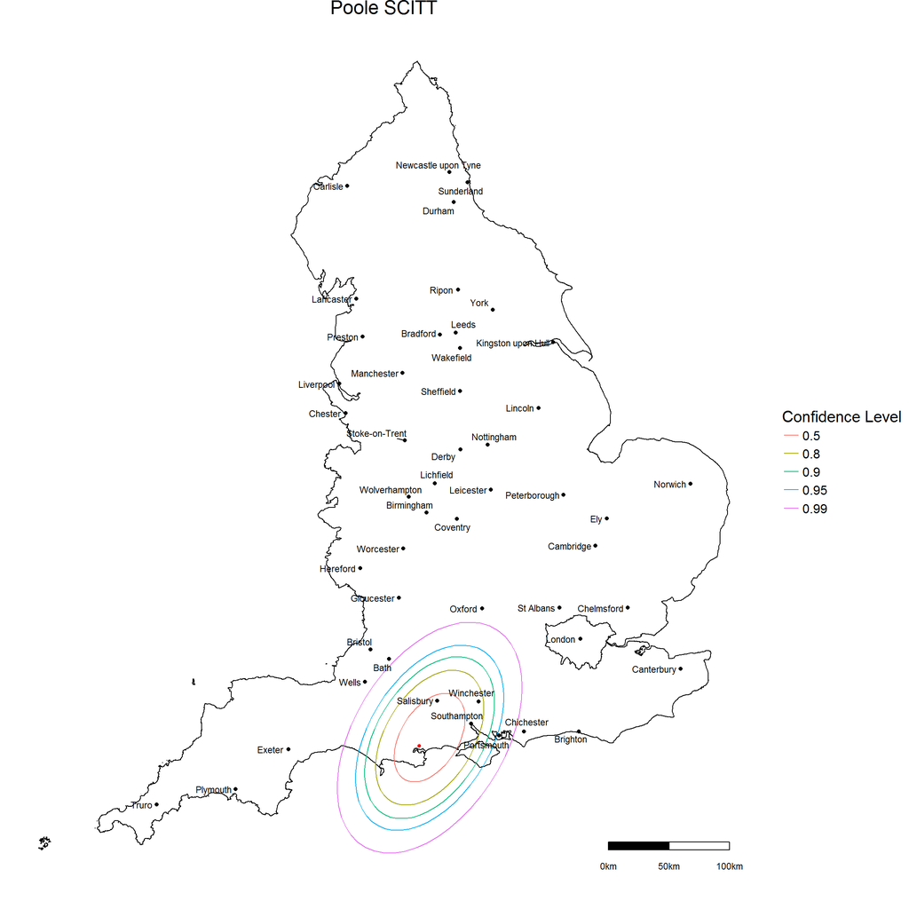

For Poole SCITT 92 % of leavers travel 25km or less to their first job as NQT and 5 % travel more than 100km. The percentage of students staying within 25km of Poole SCITT is higher than the regional average.

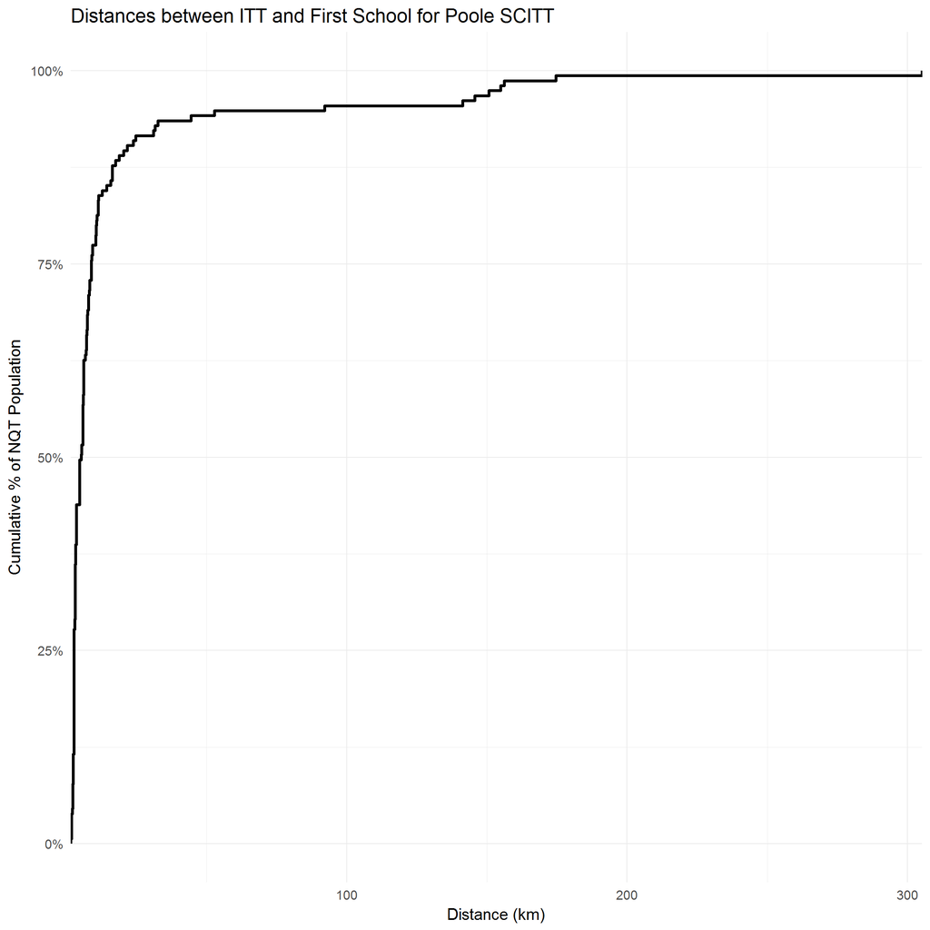

## The Learning Institute South West

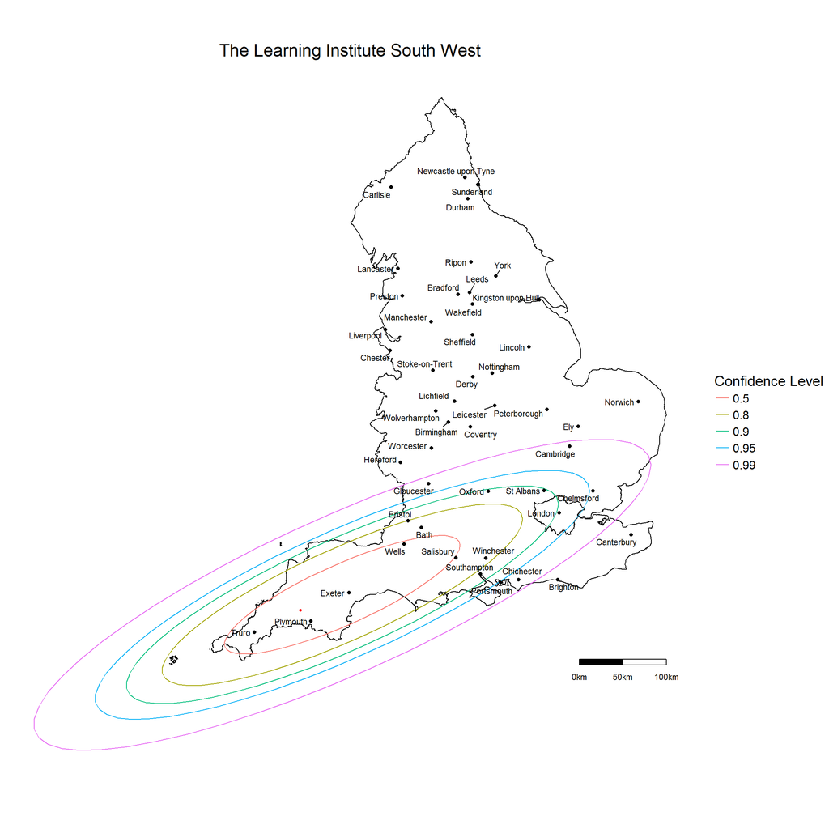

For The Learning Institute South West 36 % of leavers travel 25km or less to their first job as NQT and 22 % travel more than 100km. The percentage of students staying within 25km of The Learning Institute South West is higher than the regional average.

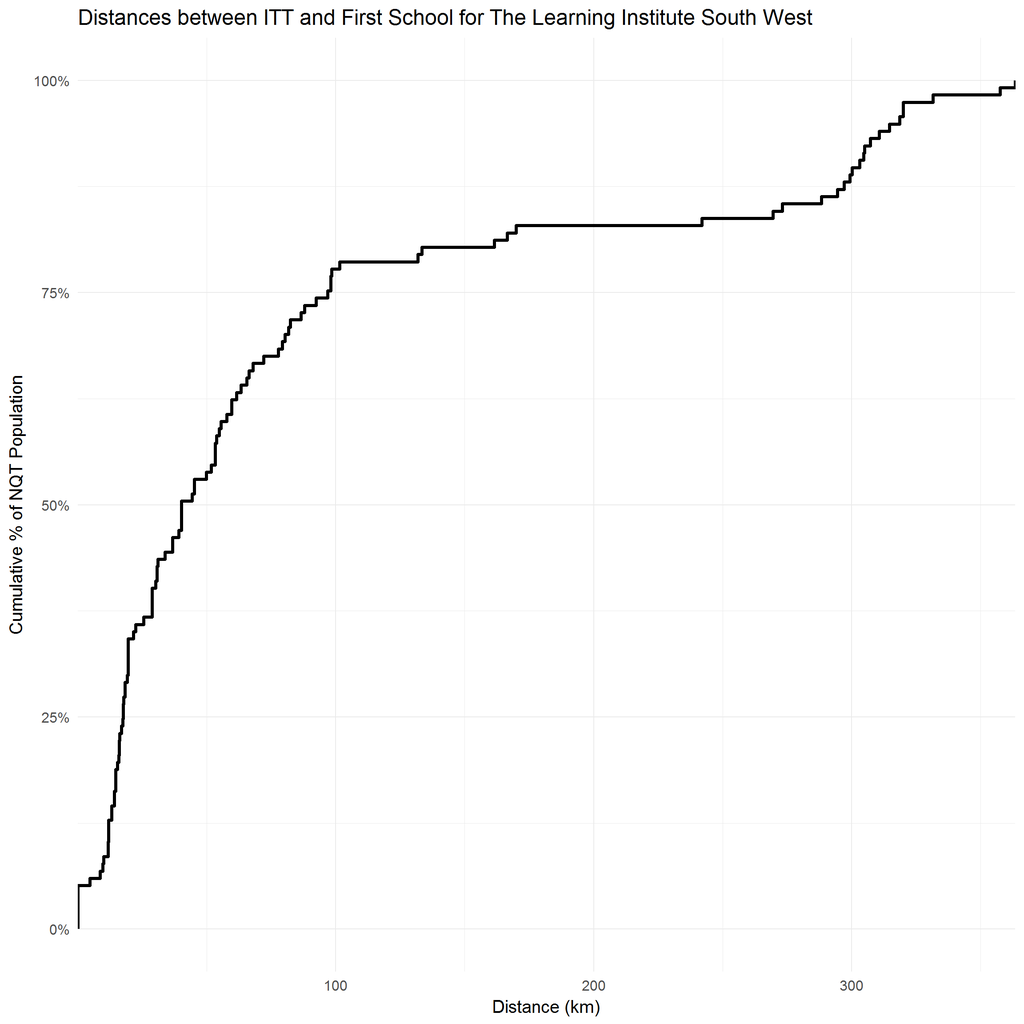